# Repair, Reconstruct, or Resect: The Fate of the Perforated Esophagus

## 0.1 Preliminaries

```r
library(skimr)
library(broom)
library(Hmisc)
library(rms)
library(tidyverse)
library(gapminder)
library(pROC)
library(ROCR)
library(simputation)
library(car)
library(leaps)
eda4 <-
  function(a.raw)
  {
    # Revised September 4, 2007 to change return phrasing
    # Revised August 28, 2008 to change to describe function
    library(Hmisc)
    a <- a.raw[!is.na(a.raw)]
    par(mfrow=c(1,3))
    boxplot(a, cex=2, main="Boxplot & mean +/- SD")
    points(1.3, mean(a), col="blue", pch=16, cex=2)
    arrows(1.3, mean(a)-sd(a),
           1.3, mean(a)+sd(a), code=3, col="blue",
           angle=40, length=.1, lwd=1.5)
    hist(a, prob=T, main="Histogram & Normal Fit",
         col="powderblue", xlab="", ylab="")
    temp.x <- seq(min(a), max(a), length=100)
    temp.y <- dnorm(temp.x, mean(a), sd(a))
    lines(temp.x, temp.y, lwd=3, col="red")
    rm(temp.x, temp.y)
    qqnorm(a, cex=2, main="Normal Q-Q plot")
    qqline(a, col="red", lwd=2)
    par(mfrow=c(1,1))
    return(list(describe(a), cbind("Standard Deviation =", sd(a))))
    rm(a)  }
```

# 1 Task 1: Data Source

The purpose of this study is to determine the factors that predict 90 day survival and hospital length of stay after esophageal perforation that required operation.

After approval from the Institutional Review Board at the Cleveland Clinic, a retrospective review was performed by myself for 3000 adult patients who were either diagnosed with esophageal perforation or who underwent esophageal surgery from 1996-2016. Patients with oropharyngeal perforations, leaks after esophagectomy and those who underwent esophageal surgery for diagnoses other than perforation were excluded. Patients with esophageal perforations but did not undergo surgery or were not seen by the thoracic surgery department were also excluded.

After exclusion, 166 patients were determined to fall within the inclusion criteria as having an esophageal perforation that was treated with an operation. The final dataset is de-identified, removing all patient identifiers.

# 2 Task 2: Load and Tidy the Data

```r
perf <- read.csv("Perf.csv",na.strings=c(""," "))

perf$Surg <- factor(perf$Surg,levels=c("Repair","Esophagectomy","Diversion"))
perf$CCF.surg <- factor(perf$CCF.surg,levels=c("Repair","Esophagectomy","Diversion"))
perf$Location <- factor(perf$Location,levels=c("Cervical","Thoracic","Abdominal"))

perf90 <- perf %>%
  select(ID, CCF.surg, Age, Charlson, Stent, Repair, WBC, Creatinine,
         Cause, Location, Xfer, Perf_CCFsurg, Bicarb, Albumin, Pitt, LOS, X90_survive)
```

## 2.1 Releveling of surgeries

Surgeries are releveled according to escalating levels of care. Stable patients with small esophageal perforations should ideally receive repairs. Stable patients with large esophageal perforations would receive esophagectomy. And unstable patients would require diversion.

## 2.2 Releveling of location

Location of perforation is releveled according to anatomic location.

```r
skim(perf90)
```

```
Skim summary statistics
 n obs: 166
 n variables: 17

Variable type: factor
 variable missing complete   n n_unique                         top_counts
    Cause       0      166 166        4 Iat: 72, Boe: 50, Oth: 25, Mal: 19
 CCF.surg       3      163 166        3   Div: 71, Rep: 64, Eso: 28, NA: 3
 Location       0      166 166        3  Abd: 111, Tho: 37, Cer: 18, NA: 0
 ordered
   FALSE
   FALSE
   FALSE

Variable type: integer
     variable missing complete   n   mean     sd p0   p25 median    p75
          Age       0      166 166 61.04   16.3   0 52.25   63    73
       Bicarb      25      141 166 24.26    4.19 12 22      24    27
     Charlson       1      165 166  1.97    2.38  0  0       1     3
           ID       0      166 166 83.5    48.06  1 42.25   83.5 124.75
          LOS       2      164 166 26.42   25.9   3 11      18    32
 Perf_CCFsurg       1      165 166 37.49  108.91  0  0       1    15
         Pitt       6      160 166  4.99    3.26  0  3       4     7
       Repair       0      166 166  0.066   0.25  0  0       0     0
        Stent       0      166 166  0.1     0.3   0  0       0     0
  X90_survive       0      166 166  0.16    0.36  0  0       0     0
         Xfer       0      166 166  0.52    0.5   0  0       1     1
 p100     hist
   92 ▁▁▁▃▃▇▆▂
   35 ▁▁▃▇▇▅▂▁
   14 ▇▅▁▁▁▁▁▁
  166 ▇▇▇▇▇▇▇▇
  176 ▇▃▁▁▁▁▁▁
  950 ▇▁▁▁▁▁▁▁
   15 ▃▇▆▅▃▁▁▁
    1 ▇▁▁▁▁▁▁▁
    1 ▇▁▁▁▁▁▁▁
    1 ▇▁▁▁▁▁▁▂
    1 ▇▁▁▁▁▁▁▇

Variable type: numeric
   variable missing complete   n  mean   sd  p0  p25 median   p75  p100
    Albumin      63      103 166  3.27 0.9  1.6 2.5    3.1   4.05  5.1
 Creatinine      28      138 166  1.07 0.86 0.3 0.7    0.84  1.15  8.1
        WBC      13      153 166 13.49 7.21 1.3 8.61  12.8  16.23 51.78
     hist
 ▂▅▇▃▂▇▂▂
 ▇▁▁▁▁▁▁▁
 ▃▇▅▁▁▁▁▁
```

# 3 Task 3: Listing of My Tibble

```r
str(perf90)
```

```
'data.frame':   166 obs. of  17 variables:
 $ ID          : int  1 2 3 4 5 6 7 8 9 10 ...
 $ CCF.surg    : Factor w/ 3 levels "Repair","Esophagectomy",..: 3 3 3 3 1 1 3 1 2 3 ...
 $ Age         : int  80 80 74 85 59 65 90 80 78 79 ...
 $ Charlson    : int  0 0 1 2 1 1 8 2 4 0 ...
 $ Stent       : int  0 0 1 0 0 0 0 0 0 0 ...
 $ Repair      : int  0 0 0 0 0 0 0 0 0 0 ...
 $ WBC         : num  14.4 14.1 7.6 11.1 13.7 ...
 $ Creatinine  : num  0.75 0.8 0.6 1.02 0.76 0.9 NA 1.01 1.15 0.8 ...
 $ Cause       : Factor w/ 4 levels "Boerhaave","Iatrogenic",..: 1 2 4 2 2 2 3 1 4 1 ...
 $ Location    : Factor w/ 3 levels "Cervical","Thoracic",..: 3 3 2 3 3 2 2 3 3 3 ...
 $ Xfer        : int  1 0 0 1 0 0 0 0 1 1 ...
 $ Perf_CCFsurg: int  0 7 162 1 0 0 1 1 2 1 ...
 $ Bicarb      : int  28 22 23 23 22 20 NA 21 23 29 ...
 $ Albumin     : num  4.7 NA 3.9 3.9 2.4 4.2 NA 4 NA NA ...
 $ Pitt        : int  11 6 1 3 9 3 4 5 3 7 ...
 $ LOS         : int  6 27 29 176 42 22 20 11 32 10 ...
 $ X90_survive : int  1 0 0 0 1 0 0 0 0 0 ...
```

The tidied dataset consists of 166 subjects and 17 variables

# 4 Task 4: Code Book

[output not shown]

# 5 Task 5: My Subjects

The data describes the 166 patients who had esophageal perforations that were managed operatively at the Cleveland Clinic (CCF) from 1996-2016. Excluded were patients who were managed nonoperatively, and those who were not seen by the thoracic surgery department. The final dataset is de-identified, removing all patient identifiers.

# 6 Task 6: My Variables

The dataset contains 17 variables.

1. ID. This is the subject ID.
2. CCF.surg. This is the surgery that was performed at CCF, including any reoperation that the patient required after transfer.
3. Age. This is the patient’s age in years at the time of the esophageal perforation.
4. Charlson. This is the Charlson Deyo comorbidity index of a total of 22 conditions assigning each condition a score of 1,2,3, or 6 to give a total possible 33 points
5. Stent. This is whether or not the patient was initially managed with a stent.
6. Repair. This whether or not the patient was initially managed with operative repair.
7. WBC. This is the white blood cell count in cells/microL. This is a measure of inflammation and infection.
8. Creatinine. This is the creatinine in mg/dl. This is a measure of kidney function.
9. Cause. This is the cause of esophageal perforation. Causes include Boerhaaves meaning spontaneous or from food impaction, iatrogenic meaning caused by instrumentation during procedure, malignant meaning due to cancer or cancer related treatments, and other, which include aortoesophageal fistulas and cervical hardware erosion.
10. Location. This is where the esophagus is perforated. Either in the cervical portion (neck), thoracic portion (chest), or abdominal portion (abdomen).
11. Xfer. This is whether or not a patient was transferred from an outside hospital to CCF.
12. Perf_CCFsurg. This is the time in days from perforation to surgery performed at CCF.
13. Bicarb. This is the bicarbonate level in mEq/dl at time of presentation. This tells us the patient’s acid/base status, which is an indirect marker of sepsis.
14. Albumin. This is the albumin level in mg/dl at the time of presentation. This tells us the patient’s nutrition level.
15. Pitt. This is the Pittsburgh Severity Score. This is a score developed for esophageal perforations to assess the severity level of the perforation and ranges from 0-18 based on several criteria including, age, fever, respiratory distress, tachycardia (fast heart rate), pleural effusion, uncontained leak, hypotension (low blood pressure),and cancer.
16. LOS. This is the length of stay after surgery in days.
17. X90_survive. This is 90 day mortality or whether or not the patient died after 90 days.

# 7 Task 7: My Planned Linear Regression Model

Age

Charlson

CCF.surg

Xfer

Perf_CCFsurg

Pitt

I anticipate that Pitt and Perf_CCFsurg will be key predictors.

# 8 Task 8: My Planned Logistic Regression Model

I will predict the binary outcome of 90 day mortality using some combination of the following four variables

Age

Charlson

Perf_CCFsurg

Pitt

I anticipate that Pitt will be the only key predictor.

# 9 Task 9: Affirmation

- I am certain that it is completely appropriate for these data to be shared with anyone, without any conditions. There are no concerns about privacy or security.

# 10 Task 10: Linear Regression

## 10.1 Assessing the Need for Transformation

LOS is right skewed and BoxCox lambda value suggests a log transformation.

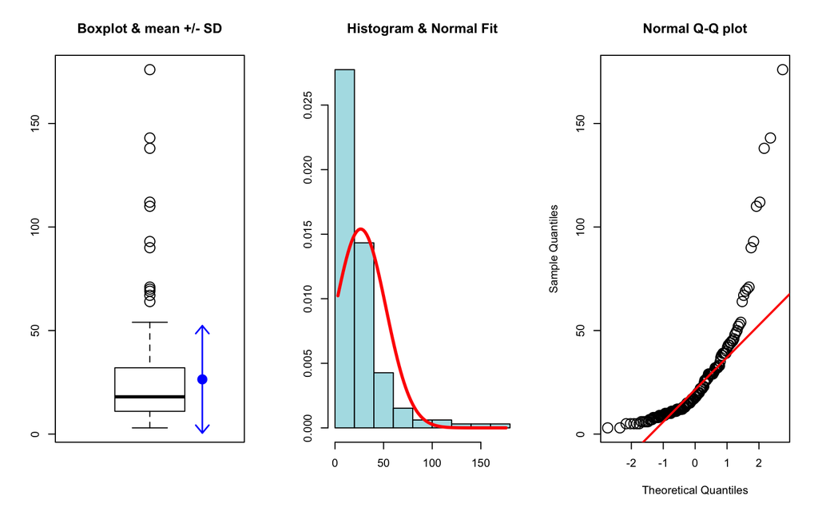

```
[[1]]
a
       n  missing distinct     Info     Mean      Gmd      .05      .10
     164        0       56    0.999    26.42    23.14     6.00     8.00
     .25      .50      .75      .90      .95
   11.00    18.00    32.00    48.70    69.85

lowest :   3   5   6   7   8, highest: 110 112 138 143 176

[[2]]
     [,1]                   [,2]
[1,] "Standard Deviation =" "25.9025982911816"
```

```r
eda4(perf90$LOS)
```

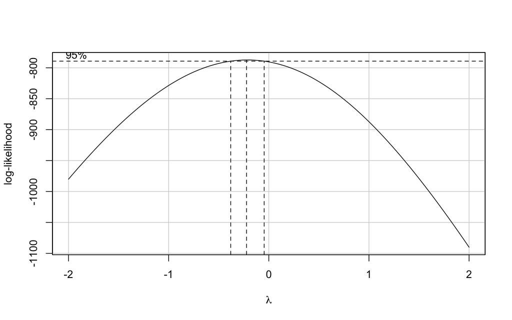

```r
boxCox(perf90$LOS ~ perf90$Age + perf90$Charlson + perf90$CCF.surg + perf90$Xfer + perf90$Perf_CCFsurg + perf90$Pitt)
```

## 10.2 Spearman Rho Plot

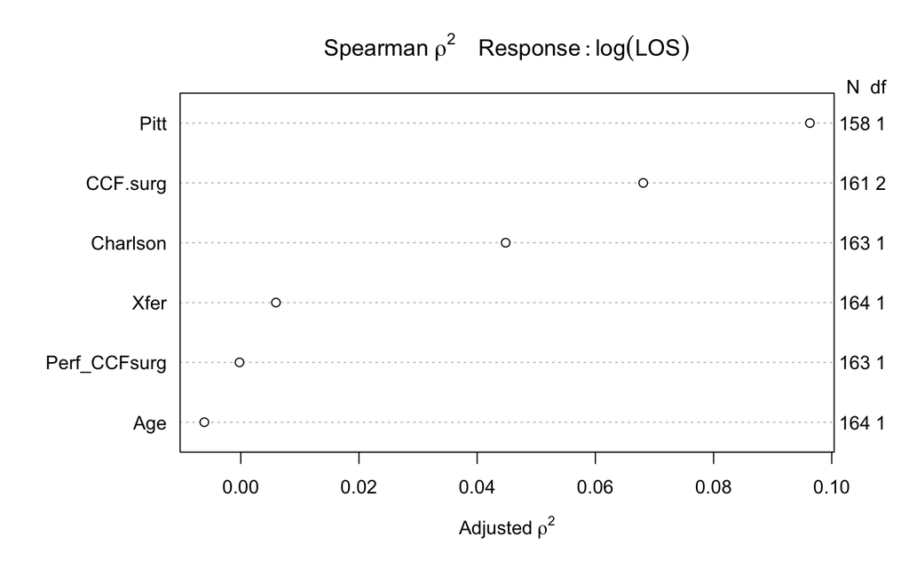

```r
plot(spearman2(log(LOS) ~ Age + Charlson + CCF.surg + Xfer + Perf_CCFsurg + Pitt, data = perf90))
```

## 10.3 Modified Kitchen Sink

R squared for this model is only 0.144.

```r
d <- datadist(perf90)
options(datadist = "d")

m.ks <- ols(log(LOS) ~ Age + Charlson + CCF.surg + Xfer + Perf_CCFsurg + Pitt,
            data = perf90, x = T, y = T)
m.ks
```

```
Frequencies of Missing Values Due to Each Variable
    log(LOS)          Age     Charlson     CCF.surg         Xfer
           2            0            1            3            0
Perf_CCFsurg         Pitt
           1            6

Linear Regression Model

 ols(formula = log(LOS) ~ Age + Charlson + CCF.surg + Xfer + Perf_CCFsurg +
     Pitt, data = perf90, x = T, y = T)


                Model Likelihood     Discrimination
                   Ratio Test           Indexes
 Obs     154    LR chi2     23.96    R2       0.144
 sigma0.7338    d.f.            7    R2 adj   0.103
 d.f.    146    Pr(> chi2) 0.0012    g        0.332

 Residuals

      Min       1Q   Median       3Q      Max
 -1.65954 -0.52328 -0.08197  0.45866  2.22101


                        Coef    S.E.   t     Pr(>|t|)
 Intercept               2.6933 0.2545 10.58 <0.0001
 Age                    -0.0020 0.0037 -0.56 0.5782
 Charlson                0.0372 0.0261  1.43 0.1560
 CCF.surg=Esophagectomy  0.0713 0.1825  0.39 0.6965
 CCF.surg=Diversion      0.3225 0.1365  2.36 0.0195
 Xfer                   -0.1074 0.1262 -0.85 0.3963
 Perf_CCFsurg           -0.0007 0.0006 -1.20 0.2340
 Pitt                    0.0472 0.0213  2.22 0.0279
```

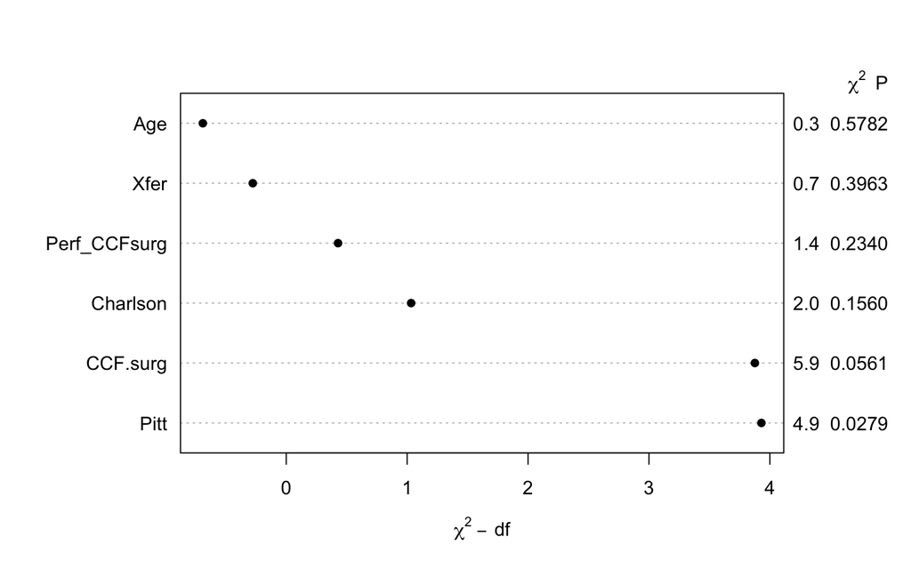

```r
plot(anova(m.ks))
```

## 10.4 Modified Kitchen Sink (with Imputation)

```r
set.seed(432001)
perf90.imp <- perf %>%
  impute_rlm(Pitt ~ Age + Cause + Malignancy +
               Perf_CCFsurg + Intub + Pressors) %>%
  select(ID, CCF.surg, Age, Charlson, Stent, Repair, WBC, Creatinine,
         Cause, Location, Xfer, Perf_CCFsurg, Bicarb, Albumin, Pitt, LOS, X90_survive)
```

After imputation, the R squared for this model only improves to 0.147.

```r
d.imp <- datadist(perf90.imp)
options(datadist = "d.imp")

imp.ks <- ols(log(LOS) ~ Age + Charlson + CCF.surg + Xfer +
                Perf_CCFsurg + Pitt,
            data = perf90.imp, x = T, y = T)
imp.ks
```

```
Frequencies of Missing Values Due to Each Variable
    log(LOS)          Age     Charlson     CCF.surg         Xfer
           2            0            1            3            0
Perf_CCFsurg         Pitt
           1            1

Linear Regression Model

 ols(formula = log(LOS) ~ Age + Charlson + CCF.surg + Xfer + Perf_CCFsurg +
     Pitt, data = perf90.imp, x = T, y = T)


                Model Likelihood     Discrimination
                   Ratio Test           Indexes
 Obs     159    LR chi2     25.25    R2       0.147
 sigma0.7244    d.f.            7    R2 adj   0.107
 d.f.    151    Pr(> chi2) 0.0007    g        0.332

 Residuals

      Min       1Q   Median       3Q      Max
 -1.66603 -0.51182 -0.09603  0.44671  2.22247


                        Coef    S.E.   t     Pr(>|t|)
 Intercept               2.7135 0.2491 10.89 <0.0001
 Age                    -0.0024 0.0036 -0.68 0.5005
 Charlson                0.0368 0.0257  1.43 0.1539
 CCF.surg=Esophagectomy  0.0819 0.1747  0.47 0.6397
 CCF.surg=Diversion      0.3336 0.1339  2.49 0.0138
 Xfer                   -0.1062 0.1231 -0.86 0.3896
 Perf_CCFsurg           -0.0007 0.0006 -1.21 0.2290
 Pitt                    0.0468 0.0209  2.24 0.0265
```

Anova suggests that the Pitt and CCF.surg add significant value to the model.

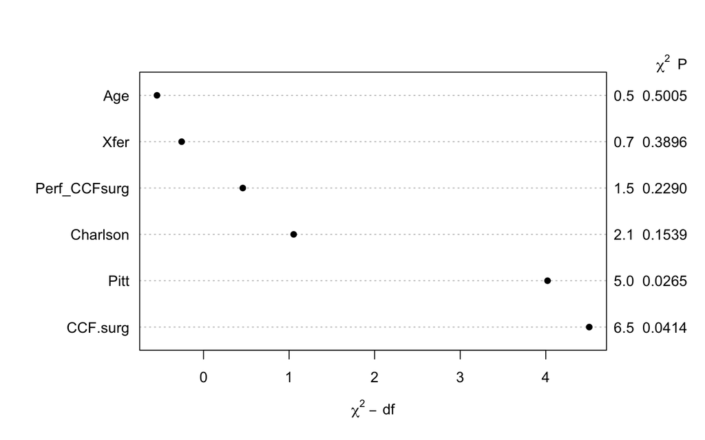

```r
plot(anova(imp.ks))
```